# exploration_template

### What is the main feature of interest in dataset ?

- Distance of the trip
- User's type
- Member gender
- Average of user's age use bike
- Average of bike trip's duration
- The day users used bike most
- The time users used bike most

### What features in the dataset that help support investigation into features of intersest ?

- Start station latitude
- Start station longitude
- End station latitude
- End station longitude

### The distribution of distance of the trip

```python
# copy code from stackoverflow to get distance link below
#"https://stackoverflow.com/questions/19412462/getting-distance-between-two-points-based-on-latitude-longitude"
from math import sin, cos, sqrt, atan2,radians

def distance (lat1,lon1,lat2,lon2):
    R = 6373.0

    lat1 = radians(lat1)
    lon1 = radians(lon1)
    lat2 = radians(lat2)
    lon2 = radians(lon2)

    dlon = lon2 - lon1
    dlat = lat2 - lat1
    a = (sin(dlat/2))**2 + cos(lat1) * cos(lat2) * (sin(dlon/2))**2
    c = 2 * atan2(sqrt(a), sqrt(1-a))
    distance = R * c
    return np.float64(round(1000*distance))
```

```python
#gettin distance of each trip
df_new['distance']=df_new.apply(lambda r :distance(r['start_station_latitude'],r['start_station_longitude'],
                                                     r['end_station_latitude'],r['end_station_longitude']),axis=1)
```

```python
df_new.head()
```

|  | duration_sec | start_time | end_time | start_station_id | start_station_name | start_station_latitude | start_station_longitude | end_station_id | end_station_name | end_station_latitude | end_station_longitude | bike_id | user_type | member_gender | bike_share_for_all_trip | user_age | distance |
| --- | --- | --- | --- | --- | --- | --- | --- | --- | --- | --- | --- | --- | --- | --- | --- | --- | --- |
| 0 | 52185 | 2019-02-28 17:32:10.145 | 2019-03-01 08:01:55.975 | 21.0 | Montgomery St BART Station (Market St at 2nd St) | 37.789625 | -122.400811 | 13.0 | Commercial St at Montgomery St | 37.794231 | -122.402923 | 4902 | Customer | Male | No | 37 | 545.0 |
| 2 | 61854 | 2019-02-28 12:13:13.218 | 2019-03-01 05:24:08.146 | 86.0 | Market St at Dolores St | 37.769305 | -122.426826 | 3.0 | Powell St BART Station (Market St at 4th St) | 37.786375 | -122.404904 | 5905 | Customer | Male | No | 49 | 2705.0 |
| 3 | 36490 | 2019-02-28 17:54:26.010 | 2019-03-01 04:02:36.842 | 375.0 | Grove St at Masonic Ave | 37.774836 | -122.446546 | 70.0 | Central Ave at Fell St | 37.773311 | -122.444293 | 6638 | Subscriber | Other | No | 32 | 261.0 |
| 4 | 1585 | 2019-02-28 23:54:18.549 | 2019-03-01 00:20:44.074 | 7.0 | Frank H Ogawa Plaza | 37.804562 | -122.271738 | 222.0 | 10th Ave at E 15th St | 37.792714 | -122.248780 | 4898 | Subscriber | Male | Yes | 47 | 2410.0 |
| 5 | 1793 | 2019-02-28 23:49:58.632 | 2019-03-01 00:19:51.760 | 93.0 | 4th St at Mission Bay Blvd S | 37.770407 | -122.391198 | 323.0 | Broadway at Kearny | 37.798014 | -122.405950 | 5200 | Subscriber | Male | No | 62 | 3333.0 |

```python
df_new['distance'].min()
```

```
0.0
```

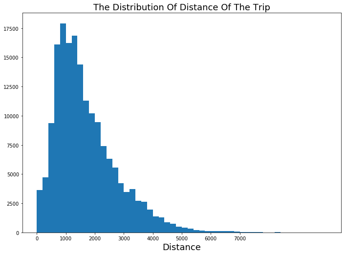

```python
#using histogram plot
bins= np.arange(0,10000+200,200)
ticks=np.arange(0,8000,1000)
labls=[ '{}'.format(v) for v in ticks ]
plt.figure(figsize=[ 11.69, 8.27])
plt.hist(data=df_new,x='distance',bins=bins);
plt.xticks(ticks,labls);
plt.xlabel('Distance',fontsize=18);
plt.title('The Distribution Of Distance Of The Trip',fontsize=18);
```

#### From this plot we see that the most bike trip's distance between 500 to 2500.

### The distribution of the duration in secound

```python
#getting minmum duration to start from it
df_new['duration_sec'].min()
```

```
61
```

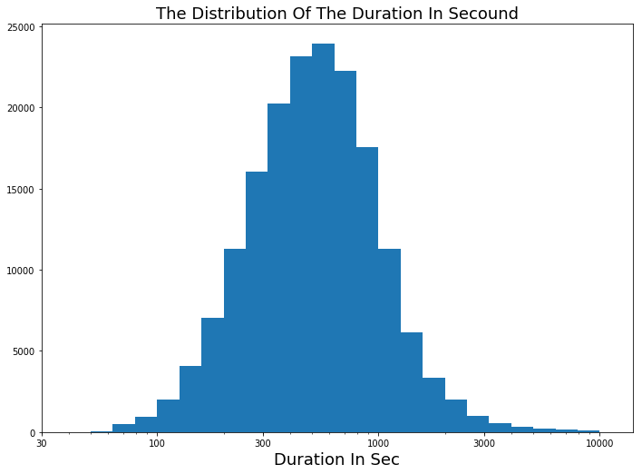

```python
#using histogram for plot
bins=10**( np.arange(1,4+0.1,0.1))
ticks=[30,100,300,1000,3000,10000]
labls=[ '{}'.format(v) for v in ticks ]
plt.figure(figsize=[ 11.69, 8.27])
plt.hist(data=df_new,x='duration_sec',bins=bins);
plt.xscale('log');
plt.xticks(ticks,labls);
plt.xlim(30);
plt.xlabel('Duration In Sec',fontsize=18);
plt.title('The Distribution Of The Duration In Secound',fontsize=18);
```

#### From this graph we see that the highest duration of trip in secound between 250 to 1000 secounds.